# Exercise week 12

Shawn Schneidereit

2021-07-03

#13E2. Rewrite the following model as a multilevel model. yi ∼ Binomial(1, pi) logit(pi) = αgroup[i] + βxi αgroup ∼ Normal(0, 1.5) β ∼ Normal(0, 0.5)

```
  brm(data = d,
      family = binomial,
      yi | trials(density) ~ 1 + (1 | group) + xi,
     prior = c(prior(normal(0, 1.5), class = Intercept),  #bar alpha
               prior(normal(0,0.5), class = b)),          # beta
```

#13E3. Rewrite the following model as a multilevel model. yi ∼ Normal(μi, σ) μi = αgroup[i] + βxi αgroup ∼ Normal(0, 5) β ∼ Normal(0, 1) σ ∼ Exponential(1)

```
  brm(data = d,
      family = gaussian,
      yi | trials(density) ~ 1 + (1 | group)+ xi,
     prior = c(prior(normal(0, 1.5), class = Intercept),  #bar alpha
               prior(normal(0,1), class = b),              # beta
               prior(exponenial(1), class = sd, group=xi)), # sigma
```

#13M1. Revisit the Reed frog survival data, data(reedfrogs), and add the predation and size treatment variables to the varying intercepts model. Consider models with either main effect alone, both main effects, as well as a model including both and their interaction. Instead of focusing on inferences about these two predictor variables, focus on the inferred variation across tanks. Explain why it changes as it does across models.

```r
data(reedfrogs, package = "rethinking")
data <- reedfrogs
data %>% glimpse()
```

```
## Rows: 48
## Columns: 5
## $ density  <int> 10, 10, 10, 10, 10, 10, 10, 10, 10, 10, 10, 10, 10, 10, 10, 1…
## $ pred     <fct> no, no, no, no, no, no, no, no, pred, pred, pred, pred, pred,…
## $ size     <fct> big, big, big, big, small, small, small, small, big, big, big…
## $ surv     <int> 9, 10, 7, 10, 9, 9, 10, 9, 4, 9, 7, 6, 7, 5, 9, 9, 24, 23, 22…
## $ propsurv <dbl> 0.90, 1.00, 0.70, 1.00, 0.90, 0.90, 1.00, 0.90, 0.40, 0.90, 0…
```

```r
data <- data %>%
  mutate(tank = 1:nrow(data))
```

```r
m_size <- brm(data = data,
      family = binomial,
      surv | trials(density) ~ 1 + size + (1 | tank),
      prior = c(prior(normal(0, 1.5), class = Intercept),
      prior(normal(0, 0.5), class = b)),
      prior(exponential(1), class = sd),
      iter = 5000, warmup = 1000, chains = 4, cores = 4,
      sample_prior = "yes",
      seed = 25)
```

```r
pp_check(m_size)
```

```
## Using 10 posterior samples for ppc type 'dens_overlay' by default.
```

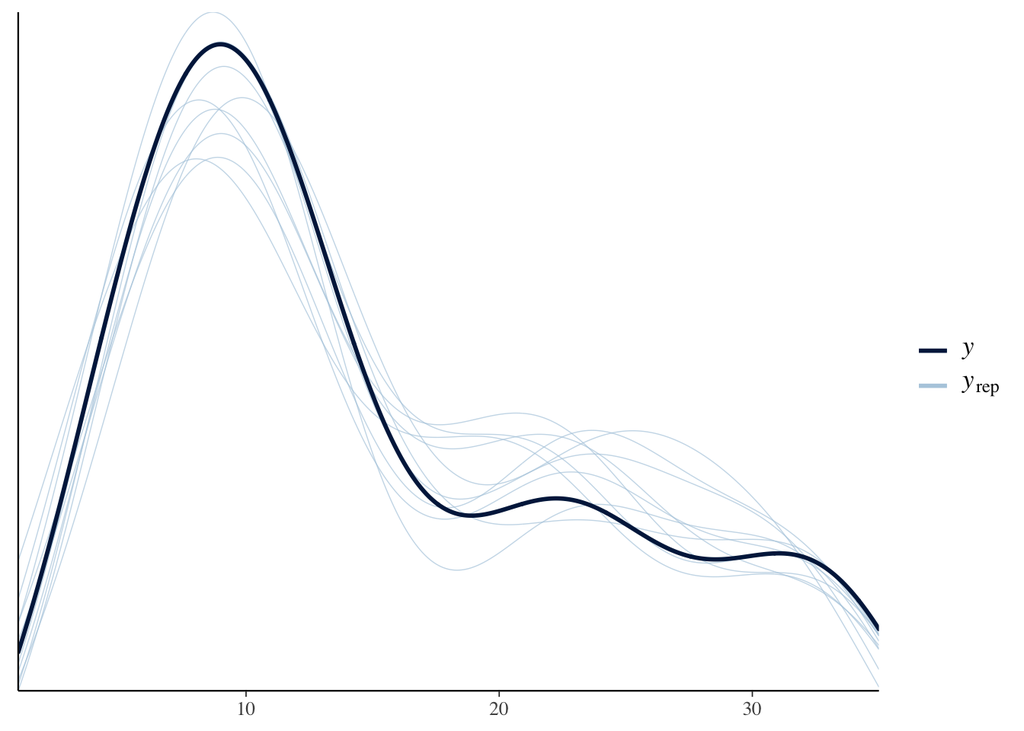

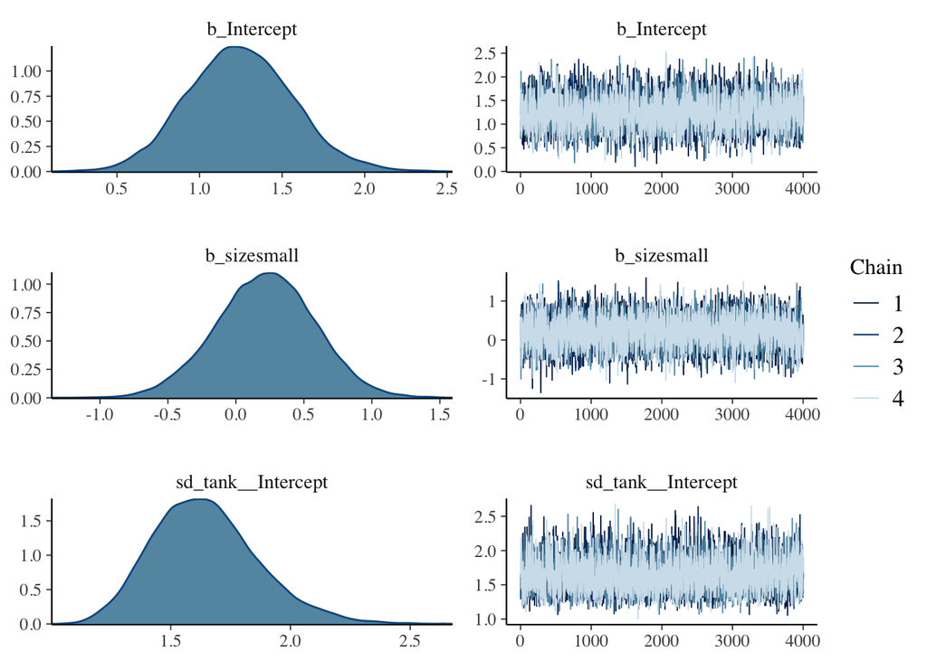

```r
plot(m_size)
```

```r
summary(m_size)
```

```
##  Family: binomial
##   Links: mu = logit
## Formula: surv | trials(density) ~ 1 + size + (1 | tank)
##          autocor ~ tructure(list(), class = "formula", .Environment = <environment>)
##    Data: data (Number of observations: 48)
## Samples: 4 chains, each with iter = 5000; warmup = 1000; thin = 1;
##          total post-warmup samples = 16000
##
## Group-Level Effects:
## ~tank (Number of levels: 48)
##               Estimate Est.Error l-95% CI u-95% CI Rhat Bulk_ESS Tail_ESS
## sd(Intercept)     1.65      0.22     1.26     2.13 1.00     3794     7240
##
## Population-Level Effects:
##           Estimate Est.Error l-95% CI u-95% CI Rhat Bulk_ESS Tail_ESS
## Intercept     1.25      0.32     0.64     1.89 1.00     3079     6019
## sizesmall     0.22      0.36    -0.50     0.92 1.00     4392     7692
##
## Samples were drawn using sampling(NUTS). For each parameter, Bulk_ESS
## and Tail_ESS are effective sample size measures, and Rhat is the potential
## scale reduction factor on split chains (at convergence, Rhat = 1).
```

```r
p_size <- mcmc_plot(m_size)
```

```r
m_pred <- brm(data = data,
      family = binomial,
      surv | trials(density) ~ 1 + pred + (1 | tank),
      prior = c(prior(normal(0, 1.5), class = Intercept),
      prior(normal(0, 0.5), class = b)),
      prior(exponential(1), class = sd),
      iter = 5000, warmup = 1000, chains = 4, cores = 4,
      sample_prior = "yes",
      seed = 25)
```

```r
pp_check(m_pred)
```

```
## Using 10 posterior samples for ppc type 'dens_overlay' by default.
```

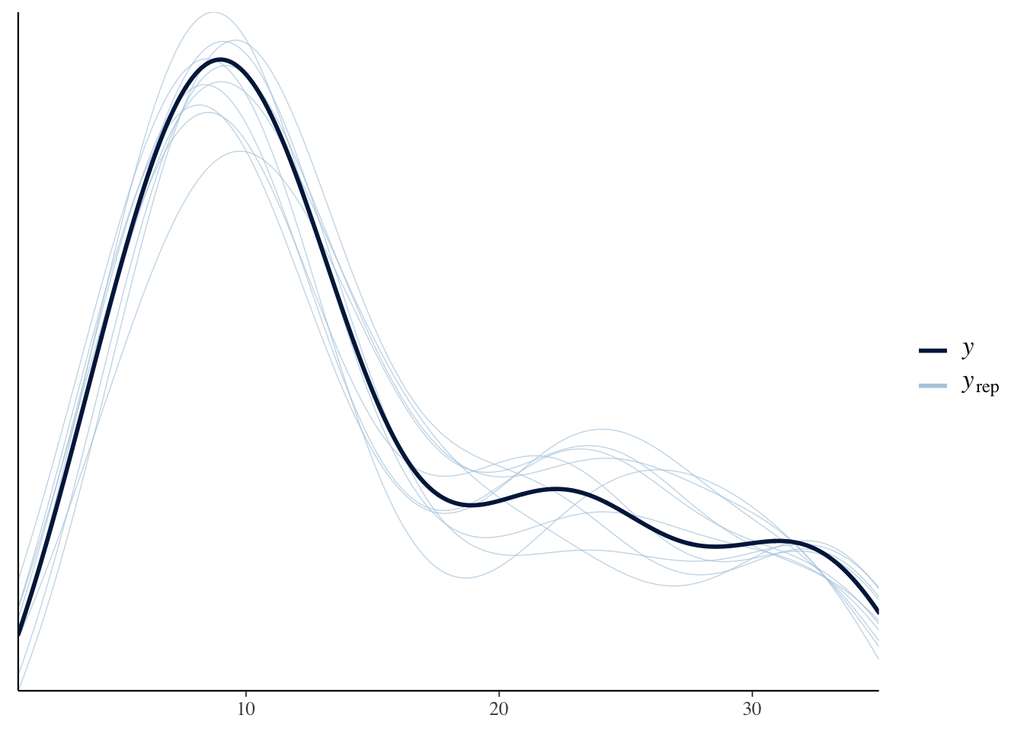

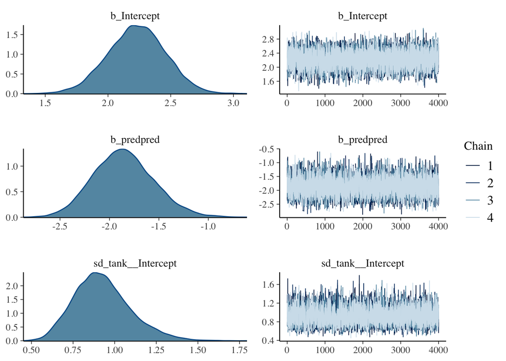

```r
plot(m_pred)
```

```r
summary(m_pred)
```

```
##  Family: binomial
##   Links: mu = logit
## Formula: surv | trials(density) ~ 1 + pred + (1 | tank)
##          autocor ~ tructure(list(), class = "formula", .Environment = <environment>)
##    Data: data (Number of observations: 48)
## Samples: 4 chains, each with iter = 5000; warmup = 1000; thin = 1;
##          total post-warmup samples = 16000
##
## Group-Level Effects:
## ~tank (Number of levels: 48)
##               Estimate Est.Error l-95% CI u-95% CI Rhat Bulk_ESS Tail_ESS
## sd(Intercept)     0.93      0.17     0.63     1.31 1.00     5347     7666
##
## Population-Level Effects:
##           Estimate Est.Error l-95% CI u-95% CI Rhat Bulk_ESS Tail_ESS
## Intercept     2.23      0.23     1.77     2.67 1.00     9868    11500
## predpred     -1.86      0.31    -2.43    -1.22 1.00     7723     9009
##
## Samples were drawn using sampling(NUTS). For each parameter, Bulk_ESS
## and Tail_ESS are effective sample size measures, and Rhat is the potential
## scale reduction factor on split chains (at convergence, Rhat = 1).
```

```r
p_pred <- mcmc_plot(m_pred)
```

```r
m_size_pred <-  brm(data = data,
      family = binomial,
      surv | trials(density) ~ 1 + size + pred + (1 | tank),
      prior = c(prior(normal(0, 1.5), class = Intercept),
      prior(normal(0, 0.5), class = b),
      prior(exponential(1), class = sd)),
      iter = 5000, warmup = 1000, chains = 4, cores = 4,
      sample_prior = "yes",
      seed = 25)
```

```r
pp_check(m_size_pred)
```

```
## Using 10 posterior samples for ppc type 'dens_overlay' by default.
```

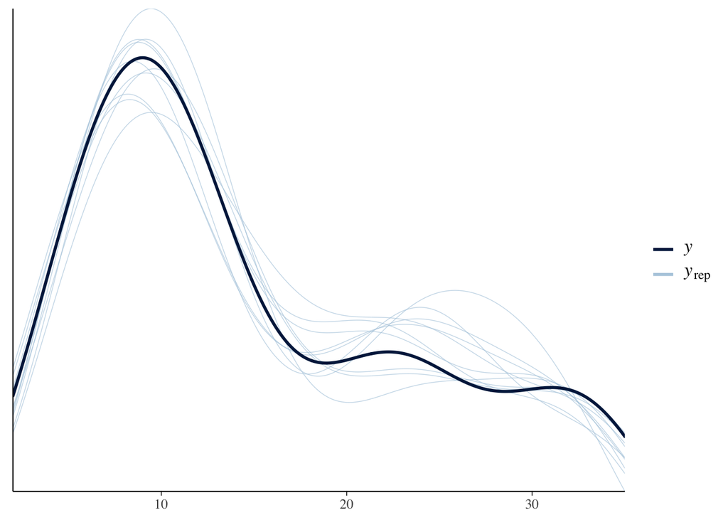

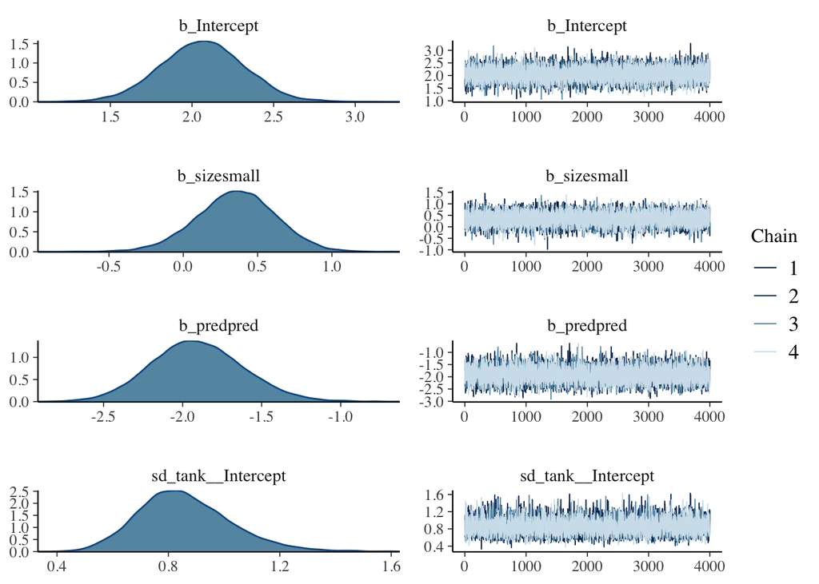

```r
plot(m_size_pred)
```

```r
summary(m_size_pred)
```

```
##  Family: binomial
##   Links: mu = logit
## Formula: surv | trials(density) ~ 1 + size + pred + (1 | tank)
##    Data: data (Number of observations: 48)
## Samples: 4 chains, each with iter = 5000; warmup = 1000; thin = 1;
##          total post-warmup samples = 16000
##
## Group-Level Effects:
## ~tank (Number of levels: 48)
##               Estimate Est.Error l-95% CI u-95% CI Rhat Bulk_ESS Tail_ESS
## sd(Intercept)     0.86      0.17     0.57     1.23 1.00     5727     7155
##
## Population-Level Effects:
##           Estimate Est.Error l-95% CI u-95% CI Rhat Bulk_ESS Tail_ESS
## Intercept     2.06      0.26     1.56     2.57 1.00    12659    11755
## sizesmall     0.36      0.27    -0.18     0.87 1.00    12106    10701
## predpred     -1.91      0.29    -2.46    -1.31 1.00     9256     8996
##
## Samples were drawn using sampling(NUTS). For each parameter, Bulk_ESS
## and Tail_ESS are effective sample size measures, and Rhat is the potential
## scale reduction factor on split chains (at convergence, Rhat = 1).
```

```r
p_size_pred <- mcmc_plot(m_size_pred)
```

```r
m_inter <- brm(data = data,
      family = binomial,
      surv | trials(density) ~ 1 + size + pred + size:pred + (1 | tank),# addition + interaction
      prior = c(prior(normal(0, 1.5), class = Intercept),
      prior(normal(0, 0.5), class = b),
      prior(exponential(1), class = sd)),
      iter = 5000, warmup = 1000, chains = 4, cores = 4,
      sample_prior = "yes",
      seed = 25)
```

```r
pp_check(m_inter)
```

```
## Using 10 posterior samples for ppc type 'dens_overlay' by default.
```

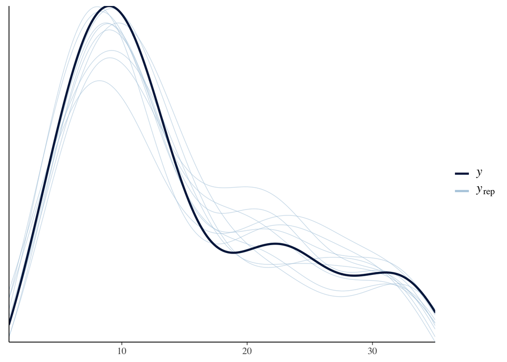

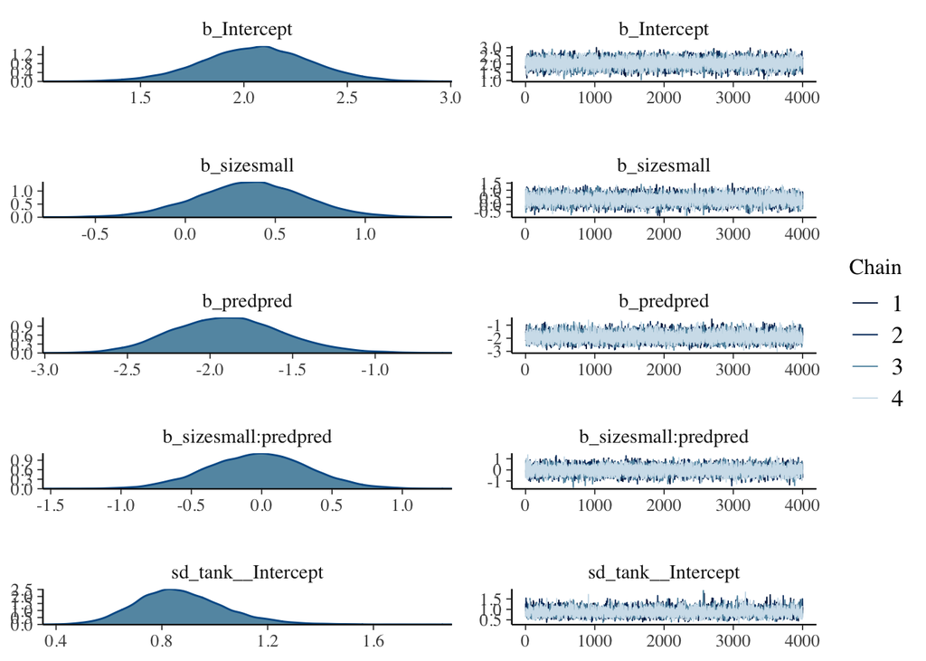

```r
plot(m_inter)
```

```r
summary(m_inter)
```

```
##  Family: binomial
##   Links: mu = logit
## Formula: surv | trials(density) ~ 1 + size + pred + size:pred + (1 | tank)
##    Data: data (Number of observations: 48)
## Samples: 4 chains, each with iter = 5000; warmup = 1000; thin = 1;
##          total post-warmup samples = 16000
##
## Group-Level Effects:
## ~tank (Number of levels: 48)
##               Estimate Est.Error l-95% CI u-95% CI Rhat Bulk_ESS Tail_ESS
## sd(Intercept)     0.87      0.17     0.58     1.24 1.00     4727     8966
##
## Population-Level Effects:
##                    Estimate Est.Error l-95% CI u-95% CI Rhat Bulk_ESS Tail_ESS
## Intercept              2.06      0.26     1.54     2.57 1.00    10255    11556
## sizesmall              0.36      0.30    -0.25     0.96 1.00    12300    11424
## predpred              -1.89      0.33    -2.51    -1.20 1.00     6860     9302
## sizesmall:predpred    -0.03      0.36    -0.73     0.67 1.00    10435    10556
##
## Samples were drawn using sampling(NUTS). For each parameter, Bulk_ESS
## and Tail_ESS are effective sample size measures, and Rhat is the potential
## scale reduction factor on split chains (at convergence, Rhat = 1).
```

```r
p_inter <- mcmc_plot(m_inter)
```

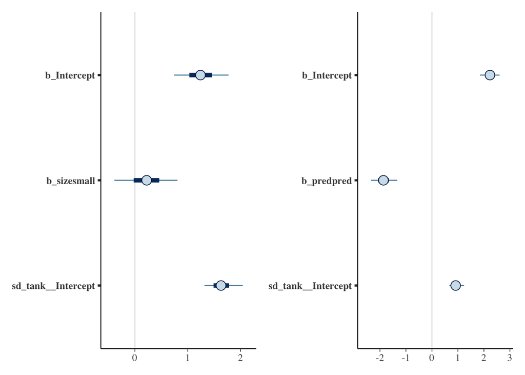

```r
(p_size | p_pred)
```

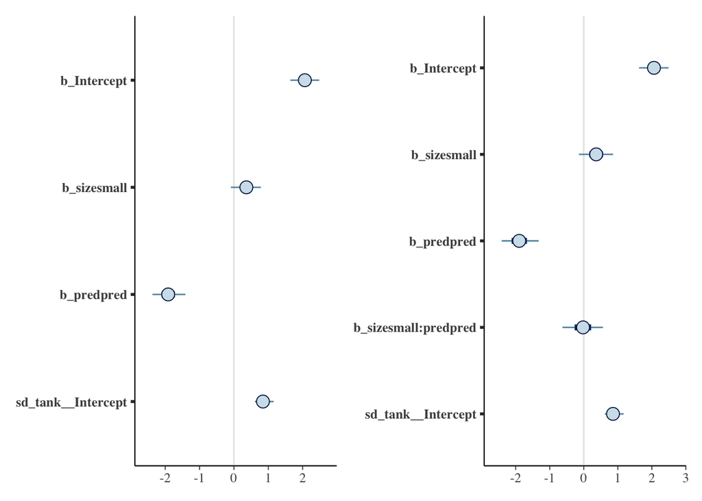

```r
(p_size_pred | p_inter)
```

#13M2. Compare the models you fit just above, using WAIC. Can you reconcile the differences in WAIC with the posterior distributions of the models?

```r
# Adding criteria to the model and comparing it with the models of 12H1
waic_size <- add_criterion(m_size, criterion = "waic")
waic_pred <- add_criterion(m_pred, criterion = "waic")
waic_size_pred <- add_criterion(m_size_pred, criterion = "waic")
waic_inter <- add_criterion(m_inter, criterion = "waic")
comparison_waic <- loo_compare(waic_size, waic_pred, waic_size_pred, waic_inter, criterion = "waic")
print(comparison_waic, simplify = FALSE)
```

```
##                elpd_diff se_diff elpd_waic se_elpd_waic p_waic se_p_waic waic
## waic_pred         0.0       0.0   -99.0       4.1         19.1    1.6     198.1
## waic_inter       -0.6       0.6   -99.6       4.0         19.3    1.6     199.3
## waic_size_pred   -0.9       0.7   -99.9       4.1         19.5    1.7     199.8
## waic_size        -1.2       2.0  -100.3       3.7         21.2    0.8     200.5
##                se_waic
## waic_pred         8.1
## waic_inter        8.0
## waic_size_pred    8.1
## waic_size         7.4
```

```r
loo_size <- add_criterion(m_size, criterion = "loo")
loo_pred <- add_criterion(m_pred, criterion = "loo")
loo_size_pred <- add_criterion(m_size_pred, criterion = "loo")
loo_inter <- add_criterion(m_inter, criterion = "loo")
comparison_loo <- loo_compare(loo_size, loo_pred, loo_size_pred, loo_inter, criterion = "loo")
print(comparison_loo, simplify = FALSE)
```

```
##               elpd_diff se_diff elpd_loo se_elpd_loo p_loo  se_p_loo looic
## loo_pred         0.0       0.0  -108.7      5.3        28.8    3.0    217.5
## loo_size_pred   -0.6       1.3  -109.3      5.2        28.9    3.0    218.6
## loo_inter       -0.7       1.1  -109.4      5.2        29.1    3.0    218.8
## loo_size        -6.3       3.1  -115.1      4.4        36.0    1.8    230.1
##               se_looic
## loo_pred        10.7
## loo_size_pred   10.4
## loo_inter       10.5
## loo_size         8.8
```

Yes, the differences in WAIC (and loo) can be reconciled with the in posterior distributions, as based on the compairison tables it can be seen that all three models that contain predation as a variable have relatively compairable elpd_loo values, where as the size model has a outlying low score.